# CSB & Weather Data Analysis

This notebook merges the processed Crop Sequence Boundaries (CSB) acreage data with aggregated weather data to explore relationships between climate variables and planting decisions.

```python
# Import libraries
import pandas as pd
import geopandas as gpd
import matplotlib.pyplot as plt
import seaborn as sns
import numpy as np
import os

# Set plot style
sns.set_theme(style="whitegrid")
%matplotlib inline
```

```python
# Define Paths
# Note: Adjust relative paths if running from a different directory
csb_path = "../data/merged_data/merged_CSB_total.csv"
weather_path = "../data/ny_weather_combined.feather"

# 1. Load CSB Data
if os.path.exists(csb_path):
    csb_df = pd.read_csv(csb_path)
    print(f"CSB Data Loaded: {csb_df.shape}")
else:
    print(f"Error: CSB file not found at {csb_path}")

# 2. Load Weather Data
if os.path.exists(weather_path):
    weather_df = pd.read_feather(weather_path)
    print(f"Weather Data Loaded: {weather_df.shape}")
else:
    print(f"Error: Weather file not found at {weather_path}")
```

```
CSB Data Loaded: (22563, 6)
Weather Data Loaded: (16740, 110)
```

# 3. Process & Aggregate Weather Data

# Goal: Create Annual-County level weather metrics (e.g., Total Precip during Growing Season)

```python
if 'weather_df' in locals():
    # Convert dates
    weather_df['start_date'] = pd.to_datetime(weather_df['start_date'])
    weather_df['Year'] = weather_df['start_date'].dt.year
    weather_df['Month'] = weather_df['start_date'].dt.month

    # Filter for Growing Season (April - October)
    # Adjust months as needed for specific crops
    growing_season = weather_df[weather_df['Month'].between(4, 10)]

    # Aggregate
    weather_annual = growing_season.groupby(['county_name', 'Year']).agg({
        'totr': 'sum',       # Total Rainfall
        'avgt': 'mean',      # Average Temperature
        'gdd_b10': 'sum',    # Growing Degree Days (Base 10C approx Base 50F)
        'mint': 'min',       # Minimum Temperature recorded
        'maxt': 'max'        # Maximum Temperature recorded
    }).reset_index()

    # Rename columns for merging
    weather_annual.rename(columns={
        'county_name': 'CNTY',
        'totr': 'Total_Precip_AprOct',
        'avgt': 'Avg_Temp_AprOct',
        'gdd_b10': 'GDD_AprOct',
        'mint': 'Min_Temp_AprOct',
        'maxt': 'Max_Temp_AprOct'
    }, inplace=True)

    print("Weather Aggregation Complete.")
    display(weather_annual.head())
```

```
Weather Aggregation Complete.
```

|  | CNTY | Year | Total_Precip_AprOct | Avg_Temp_AprOct | GDD_AprOct | Min_Temp_AprOct | Max_Temp_AprOct |
| --- | --- | --- | --- | --- | --- | --- | --- |
| 0 | Albany | 2008 | 6.34 | 55.42 | 557.7 | 33.9 | 85.7 |
| 1 | Albany | 2009 | 7.42 | 54.59 | 534.4 | 31.2 | 76.3 |
| 2 | Albany | 2010 | 8.12 | 57.01 | 673.7 | 35.4 | 81.7 |
| 3 | Albany | 2011 | 13.38 | 56.45 | 656.6 | 32.6 | 79.8 |
| 4 | Albany | 2012 | 10.51 | 55.49 | 615.9 | 31.5 | 80.7 |

```python
# 3.1 Feature Engineering: Seasonal Weather Metrics & Anomalies

if 'weather_df' in locals():
    # Define seasons
    planting_season = weather_df[weather_df['Month'].between(4, 5)]
    growing_season = weather_df[weather_df['Month'].between(6, 8)]
    harvest_season = weather_df[weather_df['Month'].between(9, 10)]

    # Helper function to aggregate
    def aggregate_season(df, prefix):
        agg = df.groupby(['county_name', 'Year']).agg({
            'totr': 'sum',
            'avgt': 'mean',
            'gdd_b10': 'sum',
            'maxt': lambda x: (x > 32.2).sum() # Count days > 90F (32.2C)
        }).reset_index()
        agg.rename(columns={
            'totr': f'{prefix}_Precip',
            'avgt': f'{prefix}_AvgTemp',
            'gdd_b10': f'{prefix}_GDD',
            'maxt': f'{prefix}_HeatDays'
        }, inplace=True)
        return agg

    # Aggregate by season
    plant_agg = aggregate_season(planting_season, 'Planting')
    grow_agg = aggregate_season(growing_season, 'Growing')
    harv_agg = aggregate_season(harvest_season, 'Harvest')

    # Merge all seasonal data
    seasonal_weather = pd.merge(plant_agg, grow_agg, on=['county_name', 'Year'], how='outer')
    seasonal_weather = pd.merge(seasonal_weather, harv_agg, on=['county_name', 'Year'], how='outer')

    # Rename for consistency
    seasonal_weather.rename(columns={'county_name': 'CNTY'}, inplace=True)

    # Calculate Anomalies (Deviation from 5-year rolling average)
    # We need to sort by Year to calculate rolling stats
    seasonal_weather.sort_values(['CNTY', 'Year'], inplace=True)

    metrics = ['Planting_Precip', 'Growing_GDD', 'Growing_Precip']
    for metric in metrics:
        # Calculate 5-year rolling mean (closed window, min_periods=1)
        seasonal_weather[f'{metric}_5y_Avg'] = seasonal_weather.groupby('CNTY')[metric].transform(
            lambda x: x.rolling(window=5, min_periods=1).mean().shift(1) # Shift to use PAST 5 years
        )
        # Calculate Deviation
        seasonal_weather[f'{metric}_Anomaly'] = seasonal_weather[metric] - seasonal_weather[f'{metric}_5y_Avg']

    print("Seasonal Weather & Anomalies Created.")
    display(seasonal_weather.head())
```

```
Seasonal Weather & Anomalies Created.
```

|  | CNTY | Year | Planting_Precip | Planting_AvgTemp | Planting_GDD | Planting_HeatDays | Growing_Precip | Growing_AvgTemp | Growing_GDD | Growing_HeatDays | Harvest_Precip | Harvest_AvgTemp | Harvest_GDD | Harvest_HeatDays | Planting_Precip_5y_Avg | Planting_Precip_Anomaly | Growing_GDD_5y_Avg | Growing_GDD_Anomaly | Growing_Precip_5y_Avg | Growing_Precip_Anomaly |
| --- | --- | --- | --- | --- | --- | --- | --- | --- | --- | --- | --- | --- | --- | --- | --- | --- | --- | --- | --- | --- |
| 0 | Albany | 2008 | 5.55 | 53.477778 | 386.5 | 9 | 0.79 | 72.9 | 171.2 | 1 | NaN | NaN | NaN | NaN | NaN | NaN | NaN | NaN | NaN | NaN |
| 1 | Albany | 2009 | 5.58 | 53.422222 | 413.0 | 9 | 1.84 | 65.1 | 121.4 | 1 | NaN | NaN | NaN | NaN | 5.550000 | 0.030000 | 171.200000 | -49.800000 | 0.7900 | 1.0500 |
| 2 | Albany | 2010 | 5.74 | 56.688889 | 593.9 | 9 | 2.38 | 59.9 | 79.8 | 1 | NaN | NaN | NaN | NaN | 5.565000 | 0.175000 | 146.300000 | -66.500000 | 1.3150 | 1.0650 |
| 3 | Albany | 2011 | 11.62 | 55.277778 | 524.3 | 9 | 1.76 | 67.0 | 132.3 | 1 | NaN | NaN | NaN | NaN | 5.623333 | 5.996667 | 124.133333 | 8.166667 | 1.6700 | 0.0900 |
| 4 | Albany | 2012 | 9.87 | 54.555556 | 504.5 | 9 | 0.64 | 63.9 | 111.4 | 1 | NaN | NaN | NaN | NaN | 7.122500 | 2.747500 | 126.175000 | -14.775000 | 1.6925 | -1.0525 |

### 3.2 Distribution Analysis of Weather Variables

In this section, we examine the distribution of key weather variables:

- **Planting_Precip**: Total precipitation during planting season (April-May).
- **Growing_GDD**: Accumulated Growing Degree Days during the growing season (June-August).

We compare the original distributions with log-transformed versions to address potential skewness in the data. Understanding these distributions is crucial for statistical modeling assumptions.

```
Data Dimensions: (1116, 20)
Unique Counties: 62
Years Covered: 2008 - 2025

--- Summary Statistics (Original Data) ---
```

|  | Planting_Precip | Growing_GDD |
| --- | --- | --- |
| count | 1116.000000 | 1116.000000 |
| mean | 9.146783 | 114.741667 |
| std | 2.798521 | 34.573738 |
| min | 3.630000 | 22.300000 |
| 25% | 7.027500 | 90.375000 |
| 50% | 8.680000 | 111.800000 |
| 75% | 10.950000 | 137.300000 |
| max | 19.920000 | 216.100000 |

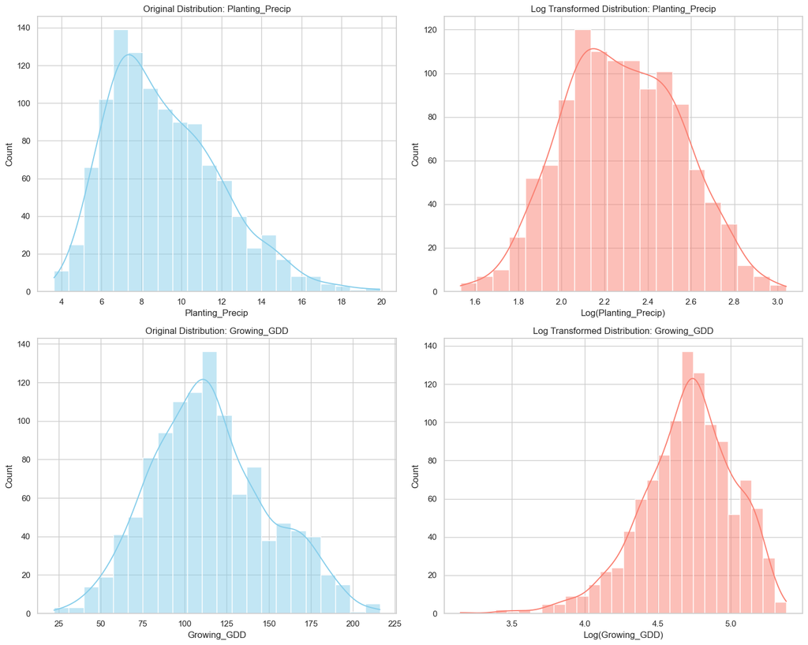

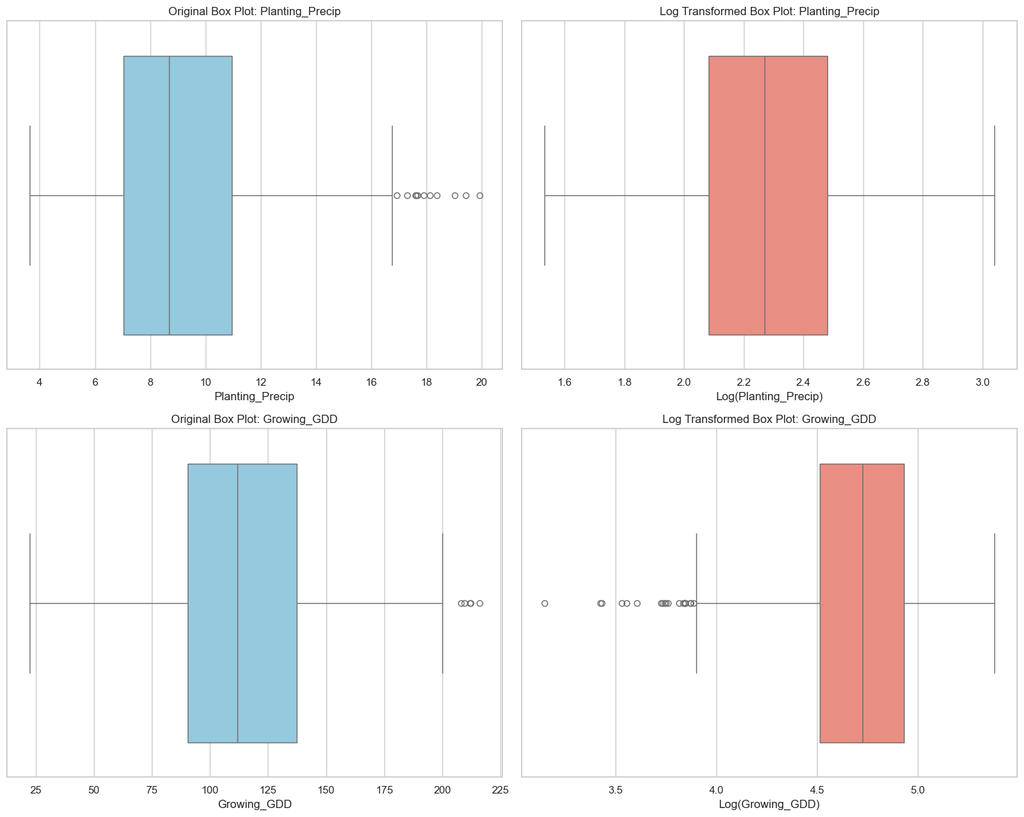

```python
# 3.2 Distribution Analysis: Weather Variables
# Analyzing the distribution of key weather variables (Original vs Log Transformed)

if 'seasonal_weather' in locals():
    # Key variables to analyze
    vars_to_analyze = ['Planting_Precip', 'Growing_GDD']

    # 1. Summary of Data Dimensions
    print(f"Data Dimensions: {seasonal_weather.shape}")
    print(f"Unique Counties: {seasonal_weather['CNTY'].nunique()}")
    if 'Year' in seasonal_weather.columns:
        years = seasonal_weather['Year'].unique()
        print(f"Years Covered: {min(years)} - {max(years)}")

    # 2. Descriptive Statistics
    print("\n--- Summary Statistics (Original Data) ---")
    display(seasonal_weather[vars_to_analyze].describe())

    # 3. Visualizing Distributions (Original vs Log Transformed)
    # Histograms
    fig, axes = plt.subplots(len(vars_to_analyze), 2, figsize=(15, 6 * len(vars_to_analyze)))

    for i, var in enumerate(vars_to_analyze):
        # Prepare Data
        data = seasonal_weather[var].dropna()
        log_data = np.log1p(data)

        # Row i, Col 0: Original Data (Histogram + KDE)
        sns.histplot(data, kde=True, ax=axes[i, 0], color='skyblue')
        axes[i, 0].set_title(f'Original Distribution: {var}')
        axes[i, 0].set_xlabel(var)

        # Row i, Col 1: Log Transformed Data (Histogram + KDE)
        sns.histplot(log_data, kde=True, ax=axes[i, 1], color='salmon')
        axes[i, 1].set_title(f'Log Transformed Distribution: {var}')
        axes[i, 1].set_xlabel(f'Log({var})')

    plt.tight_layout()
    plt.show()

    # Box Plots
    fig, axes = plt.subplots(len(vars_to_analyze), 2, figsize=(15, 6 * len(vars_to_analyze)))

    for i, var in enumerate(vars_to_analyze):
        data = seasonal_weather[var].dropna()
        log_data = np.log1p(data)

        # Row i, Col 0: Original Box Plot
        sns.boxplot(x=data, ax=axes[i, 0], color='skyblue')
        axes[i, 0].set_title(f'Original Box Plot: {var}')
        axes[i, 0].set_xlabel(var)

        # Row i, Col 1: Log Transformed Box Plot
        sns.boxplot(x=log_data, ax=axes[i, 1], color='salmon')
        axes[i, 1].set_title(f'Log Transformed Box Plot: {var}')
        axes[i, 1].set_xlabel(f'Log({var})')

    plt.tight_layout()
    plt.show()
```

```python
# 4. Merge Datasets (Enhanced)

if 'csb_df' in locals() and 'seasonal_weather' in locals():
    # Merge CSB with Seasonal Weather
    merged_df = pd.merge(csb_df, seasonal_weather, on=['CNTY', 'Year'], how='inner')

    # 4.1 Lagged Variables (Crop Rotation)
    # We want to know the acreage of the SAME crop in the PREVIOUS year
    merged_df.sort_values(['CNTY', 'Crop_Name', 'Year'], inplace=True)
    merged_df['Acres_Lag1'] = merged_df.groupby(['CNTY', 'Crop_Name'])['CSBACRES'].shift(1)

    # 4.2 Soil Data (Placeholder - assuming static soil file exists or creating dummy)
    # In a real scenario, load soil.csv with columns ['CNTY', 'Percent_Prime_Farmland']
    # Here we will simulate it or skip if file doesn't exist
    soil_path = "../data/ny_soil_data.csv" # Example path
    if os.path.exists(soil_path):
        soil_df = pd.read_csv(soil_path)
        merged_df = pd.merge(merged_df, soil_df, on='CNTY', how='left')
    else:
        print("Soil data not found, skipping soil merge.")

    print(f"Merged Dataset Shape: {merged_df.shape}")
    display(merged_df.head())
```

```
Soil data not found, skipping soil merge.
Merged Dataset Shape: (22563, 25)
```

|  | Year | CNTY | Crop_Code | CSBACRES | Source_Window | Crop_Name | Planting_Precip | Planting_AvgTemp | Planting_GDD | Planting_HeatDays | ... | Harvest_AvgTemp | Harvest_GDD | Harvest_HeatDays | Planting_Precip_5y_Avg | Planting_Precip_Anomaly | Growing_GDD_5y_Avg | Growing_GDD_Anomaly | Growing_Precip_5y_Avg | Growing_Precip_Anomaly | Acres_Lag1 |
| --- | --- | --- | --- | --- | --- | --- | --- | --- | --- | --- | --- | --- | --- | --- | --- | --- | --- | --- | --- | --- | --- |
| 5 | 2008 | Albany | 36 | 2143.855735 | 2008-2015 | Alfalfa | 5.55 | 53.477778 | 386.5 | 9 | ... | NaN | NaN | NaN | NaN | NaN | NaN | NaN | NaN | NaN | NaN |
| 1395 | 2009 | Albany | 36 | 949.807949 | 2008-2015 | Alfalfa | 5.58 | 53.422222 | 413.0 | 9 | ... | NaN | NaN | NaN | 5.550000 | 0.030000 | 171.200000 | -49.800000 | 0.7900 | 1.0500 | 2143.855735 |
| 2748 | 2010 | Albany | 36 | 1890.034305 | 2008-2015 | Alfalfa | 5.74 | 56.688889 | 593.9 | 9 | ... | NaN | NaN | NaN | 5.565000 | 0.175000 | 146.300000 | -66.500000 | 1.3150 | 1.0650 | 949.807949 |
| 4078 | 2011 | Albany | 36 | 1444.203424 | 2008-2015 | Alfalfa | 11.62 | 55.277778 | 524.3 | 9 | ... | NaN | NaN | NaN | 5.623333 | 5.996667 | 124.133333 | 8.166667 | 1.6700 | 0.0900 | 1890.034305 |
| 5415 | 2012 | Albany | 36 | 1538.625093 | 2008-2015 | Alfalfa | 9.87 | 54.555556 | 504.5 | 9 | ... | NaN | NaN | NaN | 7.122500 | 2.747500 | 126.175000 | -14.775000 | 1.6925 | -1.0525 | 1444.203424 |

5 rows × 25 columns

```
--- Correlation for Corn ---
```

|  | CSBACRES | Acres_Lag1 | Planting_Precip | Planting_Precip_Anomaly | Growing_GDD | Growing_GDD_Anomaly |
| --- | --- | --- | --- | --- | --- | --- |
| CSBACRES | 1.000000 | 0.989033 | -0.165001 | -0.004672 | 0.040135 | -0.034535 |
| Acres_Lag1 | 0.989033 | 1.000000 | -0.146162 | 0.010903 | 0.010959 | -0.050404 |
| Planting_Precip | -0.165001 | -0.146162 | 1.000000 | 0.865868 | 0.085016 | 0.349957 |
| Planting_Precip_Anomaly | -0.004672 | 0.010903 | 0.865868 | 1.000000 | 0.311002 | 0.188308 |
| Growing_GDD | 0.040135 | 0.010959 | 0.085016 | 0.311002 | 1.000000 | 0.717423 |
| Growing_GDD_Anomaly | -0.034535 | -0.050404 | 0.349957 | 0.188308 | 0.717423 | 1.000000 |

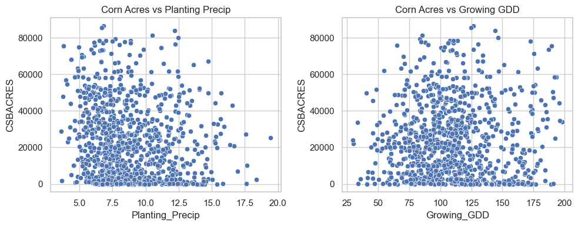

```
--- Correlation for Soybeans ---
```

|  | CSBACRES | Acres_Lag1 | Planting_Precip | Planting_Precip_Anomaly | Growing_GDD | Growing_GDD_Anomaly |
| --- | --- | --- | --- | --- | --- | --- |
| CSBACRES | 1.000000 | 0.973505 | -0.207440 | -0.057767 | 0.171019 | 0.001905 |
| Acres_Lag1 | 0.973505 | 1.000000 | -0.166162 | -0.008910 | 0.215443 | 0.005671 |
| Planting_Precip | -0.207440 | -0.166162 | 1.000000 | 0.866964 | 0.093564 | 0.363389 |
| Planting_Precip_Anomaly | -0.057767 | -0.008910 | 0.866964 | 1.000000 | 0.339925 | 0.199972 |
| Growing_GDD | 0.171019 | 0.215443 | 0.093564 | 0.339925 | 1.000000 | 0.753085 |
| Growing_GDD_Anomaly | 0.001905 | 0.005671 | 0.363389 | 0.199972 | 0.753085 | 1.000000 |

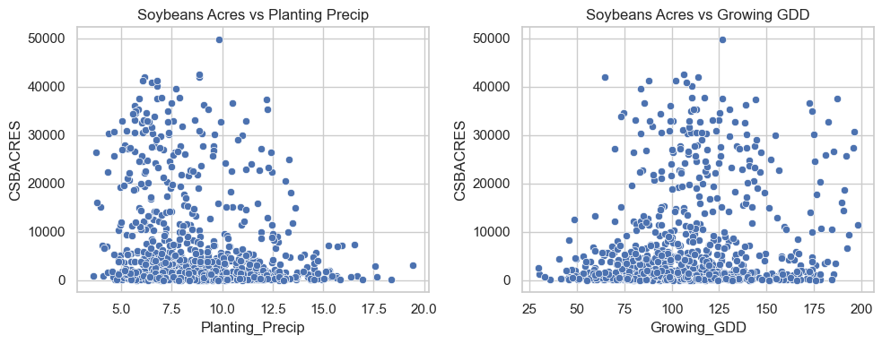

```
--- Correlation for Alfalfa ---
```

|  | CSBACRES | Acres_Lag1 | Planting_Precip | Planting_Precip_Anomaly | Growing_GDD | Growing_GDD_Anomaly |
| --- | --- | --- | --- | --- | --- | --- |
| CSBACRES | 1.000000 | 0.969369 | -0.116630 | -0.028085 | 0.011497 | 0.033796 |
| Acres_Lag1 | 0.969369 | 1.000000 | -0.124039 | -0.022989 | 0.004297 | 0.017185 |
| Planting_Precip | -0.116630 | -0.124039 | 1.000000 | 0.865778 | 0.085531 | 0.362599 |
| Planting_Precip_Anomaly | -0.028085 | -0.022989 | 0.865778 | 1.000000 | 0.326195 | 0.203162 |
| Growing_GDD | 0.011497 | 0.004297 | 0.085531 | 0.326195 | 1.000000 | 0.731524 |
| Growing_GDD_Anomaly | 0.033796 | 0.017185 | 0.362599 | 0.203162 | 0.731524 | 1.000000 |

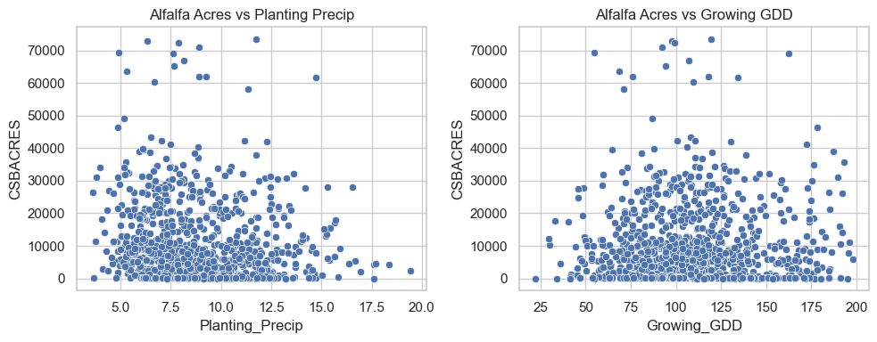

```
--- Correlation for Winter Wheat ---
```

|  | CSBACRES | Acres_Lag1 | Planting_Precip | Planting_Precip_Anomaly | Growing_GDD | Growing_GDD_Anomaly |
| --- | --- | --- | --- | --- | --- | --- |
| CSBACRES | 1.000000 | 0.947501 | -0.206154 | 0.003924 | 0.216421 | 0.019011 |
| Acres_Lag1 | 0.947501 | 1.000000 | -0.203853 | 0.007878 | 0.215964 | -0.027982 |
| Planting_Precip | -0.206154 | -0.203853 | 1.000000 | 0.867917 | 0.072126 | 0.333100 |
| Planting_Precip_Anomaly | 0.003924 | 0.007878 | 0.867917 | 1.000000 | 0.316038 | 0.162369 |
| Growing_GDD | 0.216421 | 0.215964 | 0.072126 | 0.316038 | 1.000000 | 0.769031 |
| Growing_GDD_Anomaly | 0.019011 | -0.027982 | 0.333100 | 0.162369 | 0.769031 | 1.000000 |

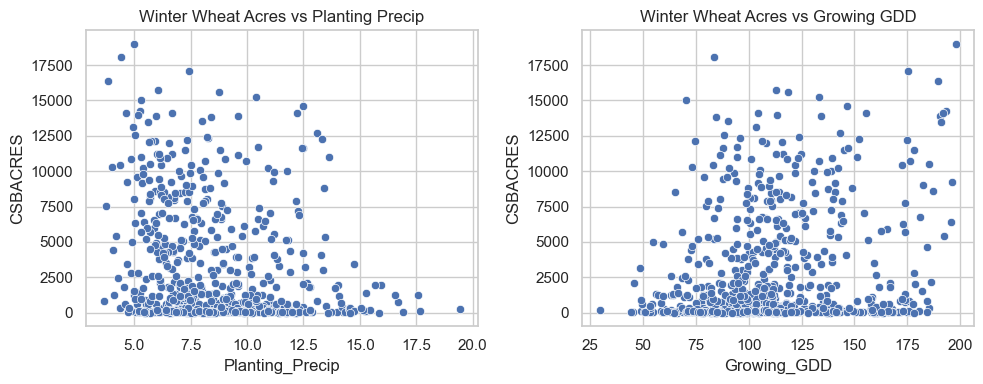

```python
# 5. Exploratory Analysis: Correlation

if 'merged_df' in locals():
    # Select numeric columns for correlation
    # We focus on major crops to avoid noise from minor ones
    major_crops = ['Corn', 'Soybeans', 'Alfalfa', 'Winter Wheat']
    subset = merged_df[merged_df['Crop_Name'].isin(major_crops)]

    # Pivot to get crops as columns if we want to see crop-specific correlations vs weather
    # Or just correlate CSBACRES with Weather for each crop group

    for crop in major_crops:
        crop_data = subset[subset['Crop_Name'] == crop]
        if crop_data.empty: continue

        print(f"\n--- Correlation for {crop} ---")
        cols = ['CSBACRES', 'Acres_Lag1', 'Planting_Precip', 'Planting_Precip_Anomaly', 'Growing_GDD', 'Growing_GDD_Anomaly']
        corr = crop_data[cols].corr()
        display(corr)

        # Simple Scatter Plot
        plt.figure(figsize=(10, 4))
        plt.subplot(1, 2, 1)
        sns.scatterplot(data=crop_data, x='Planting_Precip', y='CSBACRES')
        plt.title(f'{crop} Acres vs Planting Precip')

        plt.subplot(1, 2, 2)
        sns.scatterplot(data=crop_data, x='Growing_GDD', y='CSBACRES')
        plt.title(f'{crop} Acres vs Growing GDD')
        plt.tight_layout()
        plt.show()
```

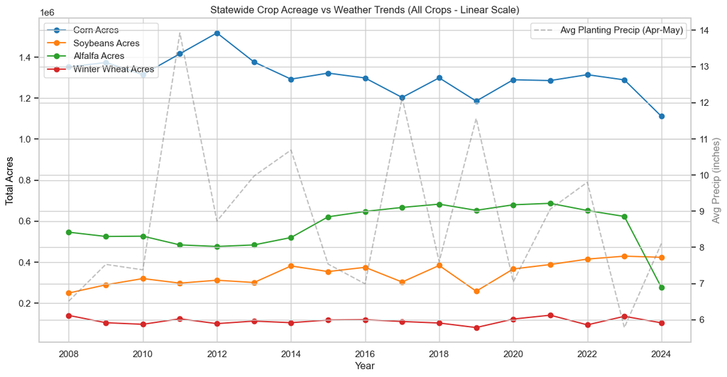

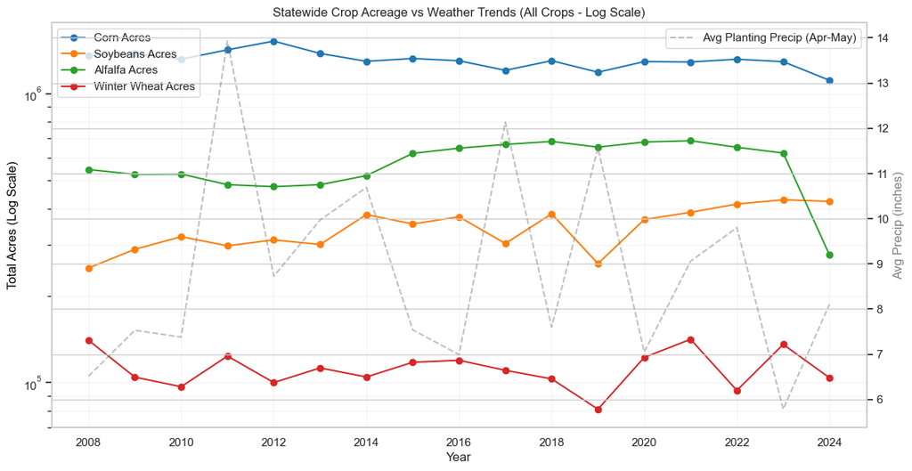

```python
# 6. Visualizing Trends Over Time (Statewide)

if 'merged_df' in locals():
    # Aggregate to State Level
    state_annual = merged_df.groupby(['Year', 'Crop_Name']).agg({
        'CSBACRES': 'sum',
        'Planting_Precip': 'mean', # Average of county averages
        'Growing_GDD': 'mean'
    }).reset_index()

    # --- 6.1 All Major Crops (Raw Scale) ---
    # Discussing Axis Scale:
    # Corn and Soybeans have vastly different total acreages than Winter Wheat.
    # If plotted on the same linear axis, Wheat looks like a flat line at the bottom.

    all_crops = ['Corn', 'Soybeans', 'Alfalfa', 'Winter Wheat']

    fig, ax1 = plt.subplots(figsize=(14, 7))

    # Plot Acreage
    colors = ['tab:blue', 'tab:orange', 'tab:green', 'tab:red']
    for i, crop in enumerate(all_crops):
        crop_data = state_annual[state_annual['Crop_Name'] == crop]
        ax1.plot(crop_data['Year'], crop_data['CSBACRES'], marker='o', label=f'{crop} Acres', color=colors[i])

    ax1.set_ylabel('Total Acres', color='black')
    ax1.set_xlabel('Year')
    ax1.legend(loc='upper left')
    ax1.grid(True)

    # Plot Weather (Secondary Axis)
    ax2 = ax1.twinx()
    precip_data = state_annual[state_annual['Crop_Name'] == 'Corn']
    ax2.plot(precip_data['Year'], precip_data['Planting_Precip'], color='gray', linestyle='--', alpha=0.5, label='Avg Planting Precip (Apr-May)')

    ax2.set_ylabel('Avg Precip (inches)', color='gray')
    ax2.legend(loc='upper right')

    plt.title('Statewide Crop Acreage vs Weather Trends (All Crops - Linear Scale)')
    plt.show()

    # --- 6.2 All Major Crops (Log Scale) ---
    # Using a Log Scale helps visualize trends for crops with vastly different magnitudes on the same plot.

    fig, ax1 = plt.subplots(figsize=(14, 7))

    # Plot Acreage
    for i, crop in enumerate(all_crops):
        crop_data = state_annual[state_annual['Crop_Name'] == crop]
        ax1.plot(crop_data['Year'], crop_data['CSBACRES'], marker='o', label=f'{crop} Acres', color=colors[i])

    ax1.set_yscale('log') # Set Y-axis to Log Scale
    ax1.set_ylabel('Total Acres (Log Scale)', color='black')
    ax1.set_xlabel('Year')
    ax1.legend(loc='upper left')
    ax1.grid(True, which="both", ls="-", alpha=0.2)

    # Plot Weather (Secondary Axis)
    ax2 = ax1.twinx()
    ax2.plot(precip_data['Year'], precip_data['Planting_Precip'], color='gray', linestyle='--', alpha=0.5, label='Avg Planting Precip (Apr-May)')

    ax2.set_ylabel('Avg Precip (inches)', color='gray')
    ax2.legend(loc='upper right')

    plt.title('Statewide Crop Acreage vs Weather Trends (All Crops - Log Scale)')
    plt.show()
```

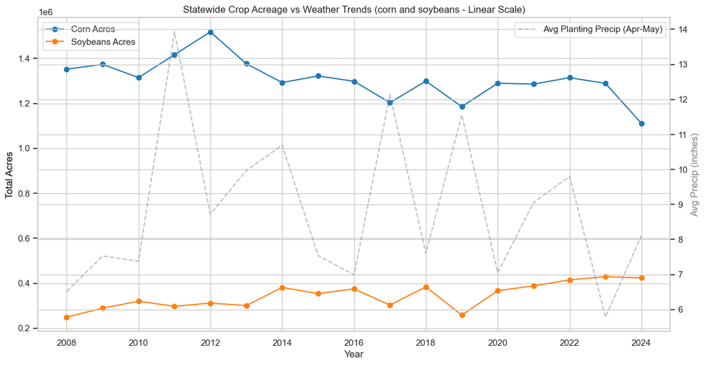

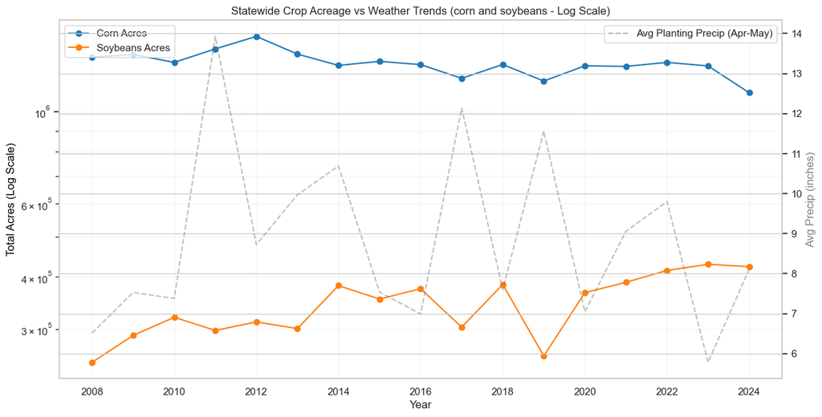

```python
# 6. Visualizing Trends Over Time (Statewide, only corn and soybeans with avg planting precip)

if 'merged_df' in locals():
    # Aggregate to State Level
    state_annual = merged_df.groupby(['Year', 'Crop_Name']).agg({
        'CSBACRES': 'sum',
        'Planting_Precip': 'mean', # Average of county averages
        'Growing_GDD': 'mean'
    }).reset_index()

    # --- 6.1 All Major Crops (Raw Scale) ---
    # Discussing Axis Scale:
    # Corn and Soybeans have vastly different total acreages than Winter Wheat.
    # If plotted on the same linear axis, Wheat looks like a flat line at the bottom.

    all_crops = ['Corn', 'Soybeans']

    fig, ax1 = plt.subplots(figsize=(14, 7))

    # Plot Acreage
    colors = ['tab:blue', 'tab:orange', 'tab:green', 'tab:red']
    for i, crop in enumerate(all_crops):
        crop_data = state_annual[state_annual['Crop_Name'] == crop]
        ax1.plot(crop_data['Year'], crop_data['CSBACRES'], marker='o', label=f'{crop} Acres', color=colors[i])

    ax1.set_ylabel('Total Acres', color='black')
    ax1.set_xlabel('Year')
    ax1.legend(loc='upper left')
    ax1.grid(True)

    # Plot Weather (Secondary Axis)
    ax2 = ax1.twinx()
    precip_data = state_annual[state_annual['Crop_Name'] == 'Corn']
    ax2.plot(precip_data['Year'], precip_data['Planting_Precip'], color='gray', linestyle='--', alpha=0.5, label='Avg Planting Precip (Apr-May)')

    ax2.set_ylabel('Avg Precip (inches)', color='gray')
    ax2.legend(loc='upper right')

    plt.title('Statewide Crop Acreage vs Weather Trends (corn and soybeans - Linear Scale)')
    plt.show()

    # --- 6.2 All Major Crops (Log Scale) ---
    # Using a Log Scale helps visualize trends for crops with vastly different magnitudes on the same plot.

    fig, ax1 = plt.subplots(figsize=(14, 7))

    # Plot Acreage
    for i, crop in enumerate(all_crops):
        crop_data = state_annual[state_annual['Crop_Name'] == crop]
        ax1.plot(crop_data['Year'], crop_data['CSBACRES'], marker='o', label=f'{crop} Acres', color=colors[i])

    ax1.set_yscale('log') # Set Y-axis to Log Scale
    ax1.set_ylabel('Total Acres (Log Scale)', color='black')
    ax1.set_xlabel('Year')
    ax1.legend(loc='upper left')
    ax1.grid(True, which="both", ls="-", alpha=0.2)

    # Plot Weather (Secondary Axis)
    ax2 = ax1.twinx()
    ax2.plot(precip_data['Year'], precip_data['Planting_Precip'], color='gray', linestyle='--', alpha=0.5, label='Avg Planting Precip (Apr-May)')

    ax2.set_ylabel('Avg Precip (inches)', color='gray')
    ax2.legend(loc='upper right')

    plt.title('Statewide Crop Acreage vs Weather Trends (corn and soybeans - Log Scale)')
    plt.show()
```